# Hands-on Exercise 1: A Layered Grammar of Graphics

Author

Andy Tai Hock Lin

Published

April 16, 2026

Modified

April 18, 2026

## 1. Overview

In this chapter, we will learn the basic principles and essential components of ggplot2, and gain hands-on experience on using these components to plot statistical graphics based on the principle of Layered Grammar of Graphics

By then end of this chapter, we will be able to apply the essential graphical elements provided by ggplot2 to create elegant and yet functional statistical graphics.

## 2 Getting Started

**Installing and loading libraries**

The code chunk below uses p_load() of [pacman](https://rpubs.com/akshaypatankar/594834) package to check if tidyverse packages are installed in the computer. If they are, then they will be launched into R.

```r
pacman::p_load(tidyverse, patchwork)
```

**Importing Data**

The code chunk below imports exam_data.csv into R environment by using read_csv() function of [readr](https://readr.tidyverse.org/) package. readr is one of the tidyverse package.

```r
exam_data <- read_csv("data/Exam_data.csv")
```

**Understanding the Data**

```r
summary(exam_data)
```

```
      ID               CLASS              GENDER              RACE
 Length:322         Length:322         Length:322         Length:322
 Class :character   Class :character   Class :character   Class :character
 Mode  :character   Mode  :character   Mode  :character   Mode  :character



    ENGLISH          MATHS          SCIENCE
 Min.   :21.00   Min.   : 9.00   Min.   :15.00
 1st Qu.:59.00   1st Qu.:58.00   1st Qu.:49.25
 Median :70.00   Median :74.00   Median :65.00
 Mean   :67.18   Mean   :69.33   Mean   :61.16
 3rd Qu.:78.00   3rd Qu.:85.00   3rd Qu.:74.75
 Max.   :96.00   Max.   :99.00   Max.   :96.00
```

- Year end examination grades of a cohort of primary 3 students from a local school.
- There are a total of seven attributes. Four of them are categorical data type and the other three are in continuous data type.
  - Categorical attributes are: ID, CLASS, GENDER and RACE.
  - Continuous attributes are: MATHS, ENGLISH and SCIENCE.

## 3 R Graphics vs ggplot

**R Graphics**

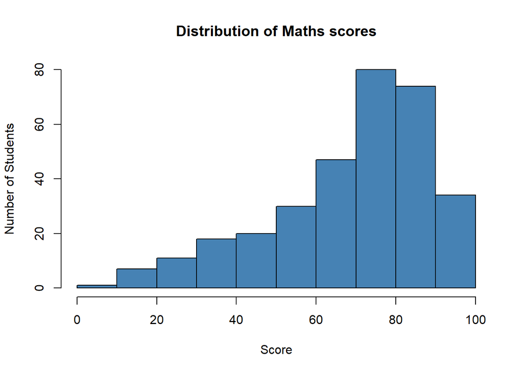

```r
hist(exam_data$MATHS,
     ylab='Number of Students',
     xlab='Score',
     main='Distribution of Maths scores',
     col='steelblue')
```

**ggplot2**

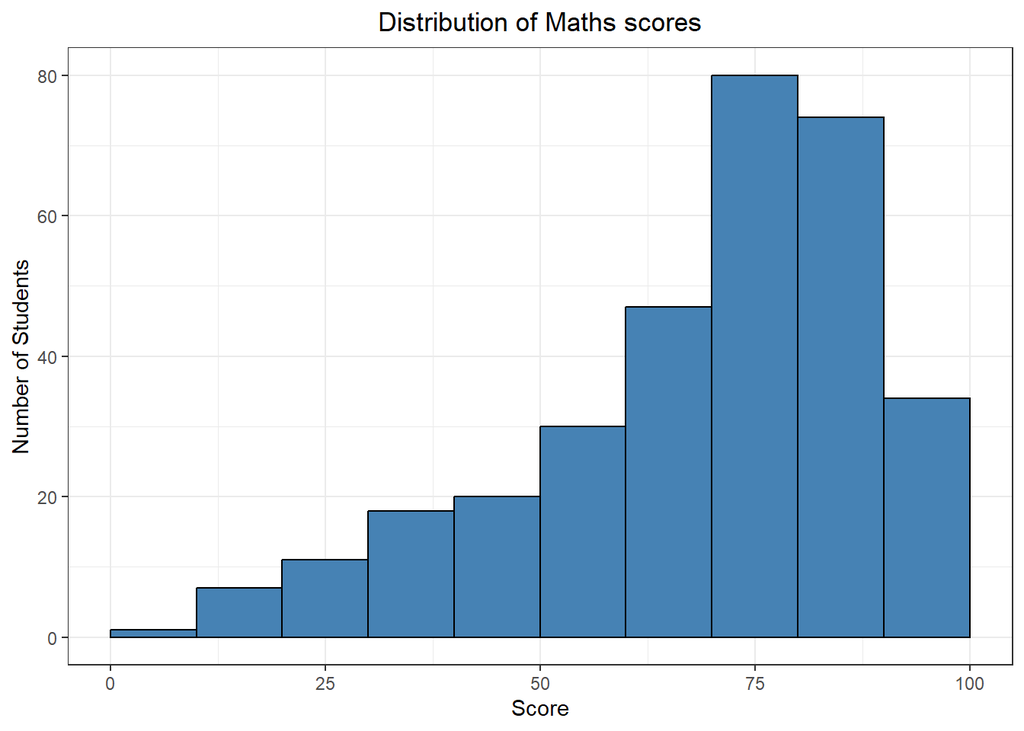

```r
ggplot(data=exam_data, aes(x = MATHS)) +
  geom_histogram(bins=10,
                 boundary = 100,
                 color="black",
                 fill="steelblue") +
  labs(x = "Score",
       y = "Number of Students",
       title = "Distribution of Maths scores")+
  theme_bw()+
  theme(plot.title = element_text(hjust = 0.5))
```

ggplot2 is preferred over the built-in plot function due to the following reason:

“The transferable skills from ggplot2 are not the idiosyncrasies of plotting syntax, but a powerful way of thinking about visualisation, as a way of mapping between variables and the visual properties of geometric objects that you can perceive.” - Hadley Wickham